# Valores de Shapley e SHAP

Interpretabilidade de Aprendizado de Máquina

**[Bruno Iochins Grisci](https://brunogrisci.github.io/)**

[Universidade Federal do Rio Grande do Sul](https://www.ufrgs.br/site/)  
[Instituto de Informática](https://www.inf.ufrgs.br/site/)  
[Departamento de Informática Teórica](https://www.inf.ufrgs.br/site/estrutura/departamentos/)  
[Programa de Pós-Graduação em Computação](https://www.inf.ufrgs.br/ppgc/)

## Aula anterior

**[Aula 08: Contrafactuais, Anchors e Recourse](https://brunogrisci.github.io/aulas-interpretabilidade/aula08.html)**

# Valores de Shapley

## O problema

Uma predição é um número. Como dividir esse número entre os atributos que o produziram?

**O que já fizemos**

Ceteris Paribus e ICE mostram **como a saída muda** quando um atributo varia.

Contrafactuais mostram **o que mudar** para virar a decisão.

LIME **aproxima** o modelo por perto.

**O que falta**

Uma resposta para: *quanto* cada valor de atributo contribuiu **para esta predição**?

E uma garantia de que a resposta é **justa** — não apenas plausível.

**A ideia**

Tratar a predição como o **prêmio de um jogo** e os valores dos atributos como os **jogadores** que o conquistaram.

A teoria dos jogos já resolveu como dividir prêmios.

Vamos construir a resposta primeiro num jogo com alunas disputando um prêmio; só depois trocaremos jogadoras por atributos.

Fontes desta aula: [Molnar, cap. Shapley Values e cap. SHAP](https://christophm.github.io/interpretable-ml-book/); vídeos [*The mathematics behind Shapley Values*](https://www.youtube.com/watch?v=UJeu29wq7d0), [*Shapley Values for Machine Learning*](https://www.youtube.com/watch?v=b9qqbFudVhI) e [*4 Significant Limitations of SHAP*](https://www.youtube.com/watch?v=CO1DwCd_bJU) de Conor O’Sullivan.

## Um prêmio para dividir

Uma competição de ciência de dados premia as três primeiras colocações.

**A tabela de prêmios**

| colocação | prêmio |
| --- | --- |
| 1.º lugar | R$ 10.000 |
| 2.º lugar | R$ 7.500 |
| 3.º lugar | R$ 5.000 |
| não participou | R$ 0 |

O prêmio depende de **quem forma a equipe** — não de quem trabalhou mais horas.

**O problema**

**Ana** e **Bia** competem juntas e ficam em 1.º lugar: **R$ 10.000**.

Bia propõe dividir ao meio: R$ 5.000 para cada.

Ana discorda: *“eu contribuí mais”*.

**Quem está certo?** Precisamos de um critério, não de uma opinião.

Chamamos de **valor de coalizão** *C(S)* o prêmio que o grupo *S* consegue. Uma **coalizão** é qualquer subconjunto de jogadoras, inclusive a vazia.

Para decidir, precisamos saber o que cada subgrupo conseguiria **sozinho**.

## Valores de coalizão: duas jogadoras

Suponha que possamos repetir a competição com cada subgrupo. Estes são os quatro resultados.

[figure not shown]

**Contribuição marginal**

Quanto o prêmio **sobe** quando uma jogadora entra numa coalizão:

$$C(S \cup \{\text{jogadora}\}) - C(S)$$

**Ana contribui mais**

Sozinha, Ana rende R$ 7.500 e Bia R$ 5.000.

Entrando na outra coalizão, Ana acrescenta R$ 5.000 e Bia acrescenta R$ 2.500.

Nas **duas** comparações, Ana contribui mais.

Uma jogadora tem várias contribuições marginais — uma para cada coalizão em que pode entrar.

## A média das contribuições marginais

Com duas jogadoras há duas coalizões possíveis de entrar, e nenhuma razão para preferir uma delas: peso 50% para cada.

[figure not shown]

Estes dois números — R$ 6.250 e R$ 3.750 — são os **valores de Shapley** deste jogo. Note que somam exatamente o prêmio.

Exemplo com os mesmos valores do vídeo [*The mathematics behind Shapley Values*](https://www.youtube.com/watch?v=UJeu29wq7d0).

## Definição, em palavras

**valor de Shapley de uma jogadora** = média ponderada das contribuições marginais dela a **todas** as coalizões em que pode entrar

**Por que “média”?**

Não sabemos em que ordem as jogadoras se juntaram. Consideramos todas as possibilidades e tiramos a média.

**Por que “ponderada”?**

Algumas coalizões são encontradas mais frequentemente do que outras. O peso é essa frequência — e vamos deduzi-la.

**Por que “todas”?**

Contribuições individuais **e** os ganhos de trabalhar em conjunto entram na conta. Nenhuma sinergia é ignorada.

Com duas jogadoras os pesos são obviamente 50% e 50%. Com três jogadoras eles deixam de ser óbvios — e é aí que a fórmula aparece.

## Três jogadoras, oito coalizões

Nova competição: Ana, Bia e Caio. Com $p$ jogadoras há $2^p$ coalizões — aqui, 8.

[figure not shown]

**Leia a treliça**

Cada caixa é uma coalizão e traz o prêmio que ela conquista.

Cada seta é a **entrada de uma jogadora**, ou seja, uma contribuição marginal.

**Quantas setas por jogadora?**

Ana pode entrar em $\emptyset$, em $\{$Bia$\}$, em $\{$Caio$\}$ e em $\{$Bia, Caio$\}$.

São $2^{p-1} = 4$ coalizões — as coalizões formadas pelas **outras** jogadoras.

## As contribuições marginais de Ana

Cada contribuição é uma subtração entre dois valores de coalizão que já estão na treliça.

| Ana entra em… | com Ana | sem Ana | contribuição marginal |
| --- | --- | --- | --- |
| ∅ (ninguém) | C({Ana}) = R$ 5.000 | C(∅) = R$ 0 | +R$ 5.000 |
| {Bia} | C({Ana, Bia}) = R$ 7.500 | C({Bia}) = R$ 5.000 | +R$ 2.500 |
| {Caio} | C({Ana, Caio}) = R$ 7.500 | C({Caio}) = R$ 0 | +R$ 7.500 |
| {Bia, Caio} | C({todos}) = R$ 10.000 | C({Bia, Caio}) = R$ 5.000 | +R$ 5.000 |

As quatro contribuições são **diferentes**: R$ 2.500, R$ 5.000, R$ 5.000 e R$ 7.500. Uma média simples daria R$ 5.000 — mas ainda não sabemos se a média simples é a correta.

Ana vale muito ao lado de Caio (que sozinho não pontua) e pouco ao lado de Bia (que sozinha já pontua). O valor de uma jogadora **depende de com quem ela está**.

## De onde vêm os pesos

Imagine que as jogadoras chegam à sala em ordem aleatória, e cada uma leva o quanto o prêmio subiu com sua chegada.

[figure not shown]

O peso de uma coalizão é a fração das ordens de chegada em que a jogadora encontra **exatamente** aquela coalizão já na sala.

## Contando as ordens

Basta contar. Ana encontra a coalizão $S$ quando (i) todas de $S$ chegam antes e (ii) todas as demais chegam depois.

**Total de ordens**

Com $p$ jogadoras há $p!$ ordens de chegada.

Aqui: $3! = 6$.

**Ordens favoráveis**

As $|S|$ jogadoras de $S$ podem chegar em $|S|!$ ordens entre si.

As $p - |S| - 1$ que faltam podem chegar em $(p-|S|-1)!$ ordens entre si.

**O peso**

$$\frac{|S|!\,(p-|S|-1)!}{p!}$$

| Ana encontra $S$ | $\|S\|$ | $\|S\|!\,(p-\|S\|-1)!$ | ordens | peso |
| --- | --- | --- | --- | --- |
| ∅ | 0 | $0!\cdot 2! = 2$ | 2 de 6 | 1/3 |
| {Bia} | 1 | $1!\cdot 1! = 1$ | 1 de 6 | 1/6 |
| {Caio} | 1 | $1!\cdot 1! = 1$ | 1 de 6 | 1/6 |
| {Bia, Caio} | 2 | $2!\cdot 0! = 2$ | 2 de 6 | 1/3 |

Os pesos somam 1: $\tfrac13+\tfrac16+\tfrac16+\tfrac13 = 1$. Coalizões **muito pequenas** e **muito grandes** pesam mais, porque há menos maneiras de formá-las.

## A fórmula, termo a termo

$$\phi_j(C)=\sum_{S\subseteq P\setminus\{j\}}
\underbrace{\frac{|S|!\left(p-|S|-1\right)!}{p!}}_{\text{peso}}
\underbrace{\bigl(C(S\cup\{j\})-C(S)\bigr)}_{\text{contribuição marginal}}$$

**$\phi_j$**

O valor de Shapley da jogadora $j$: quanto ela leva do prêmio.

**$P\setminus\{j\}$**

Todas as jogadoras **menos** $j$. Os subconjuntos $S$ são as coalizões que $j$ pode encontrar.

**$C(S)$**

O valor da coalizão $S$: o prêmio que aquele grupo conquista.

**$\sum$**

Percorre as $2^{p-1}$ coalizões possíveis, somando peso × contribuição.

$$\phi_{\text{Ana}}=\tfrac13(5.000)+\tfrac16(2.500)+\tfrac16(7.500)+\tfrac13(5.000)=\mathbf{5.000}$$

A fórmula intimida, mas é só isto: **média das contribuições marginais, ponderada pela probabilidade de cada encontro**.

## Calculadora interativa

Troque a jogadora avaliada e acompanhe as quatro linhas da soma.

Quem estamos avaliando?

| coalizão encontrada *S* | C(S ∪ {jogadora}) | C(S) | contribuição marginal | ordens | peso | peso × contribuição |
| --- | --- | --- | --- | --- | --- | --- |

soma = valor de Shapley

O peso é a fração das 3! = 6 ordens de chegada em que a jogadora encontra exatamente aquela coalizão.

Repare que Caio, que sozinho não pontua, ainda assim leva R$ 1.250: ele **ajuda** quando entra em coalizões que já existem. Não pontuar sozinho é diferente de não contribuir.

## A sala de espera

A mesma conta, vista pelas ordens de chegada: revele as ordens e veja a média convergir.

As jogadoras entram na sala em ordem aleatória. Cada uma leva o quanto o prêmio subiu com sua chegada.

| ordem de chegada | Ana | Bia | Caio | soma |
| --- | --- | --- | --- | --- |

média das ordens reveladas

**Valor de Shapley** = média das contribuições marginais sobre **todas** as ordens.

Esta é uma segunda definição, equivalente: o valor de Shapley é a **média da contribuição marginal sobre todas as ordens de chegada**. Ela será a base dos estimadores mais usados.

## Eficiência: nada sobra, nada falta

[figure not shown]

$$\sum_{j=1}^{p}\phi_j = C(P) - C(\emptyset)$$

Esta é a primeira das quatro propriedades que definem “divisão justa”. As outras três vêm a seguir.

## Os quatro axiomas

Shapley não partiu da fórmula: partiu de quatro exigências de justiça.

**1 · Eficiência**

Todo o valor é distribuído.

$$\sum_j \phi_j = C(P)$$

**2 · Simetria**

Quem contribui igual recebe igual.

Se $C(S\cup\{j\})=C(S\cup\{k\})$ para **todo** $S$, então $\phi_j=\phi_k$.

**3 · Jogador nulo**

Quem nunca muda nada recebe zero.

Se $C(S\cup\{j\})=C(S)$ para **todo** $S$, então $\phi_j=0$.

**4 · Aditividade**

Jogos independentes somam.

Num jogo com prêmios $C+C^{+}$, o valor é $\phi_j+\phi_j^{+}$.

Cuidado com o axioma 3: ele exige que a jogadora não altere **nenhuma** coalizão. Caio altera várias — só não pontua sozinho.

## O teorema de unicidade

Existe **exatamente uma** forma de dividir o valor que satisfaz os quatro axiomas: o valor de Shapley.

**Por que isso importa**

Outras divisões podem parecer justas — dividir igualmente, dividir pelo desempenho individual, dividir por horas trabalhadas.

Nenhuma delas satisfaz os quatro axiomas ao mesmo tempo.

**A consequência para a aula**

Se aceitarmos os quatro axiomas como definição de justiça, **não há escolha**: a divisão é a de Shapley.

É a única técnica de atribuição desta disciplina com esse tipo de garantia.

A unicidade é sobre a **divisão**, dado o jogo. Ela não diz que o jogo escolhido é o correto — e escolher o jogo será a decisão mais delicada quando passarmos para modelos.

Lloyd Shapley (1953), [*A Value for n-Person Games*](https://doi.org/10.1515/9781400881970-018). Nobel de Economia em 2012 (com Alvin Roth), por trabalhos em desenho de mercados.

## Lloyd Shapley

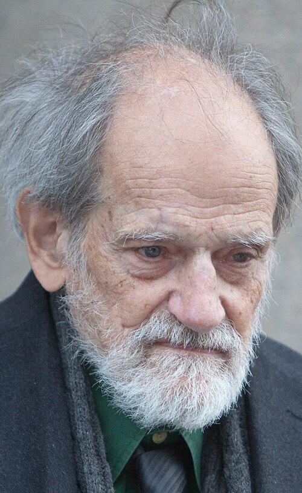

Estocolmo, dezembro de 2012.  
Foto: [Bengt Nyman](https://www.flickr.com/people/97469566@N00), [CC BY 2.0](https://creativecommons.org/licenses/by/2.0/), via Wikimedia Commons.

**Lloyd Stowell Shapley (1923–2016)**

- Matemático estadunidense, filho do astrônomo **Harlow Shapley**.
- **1943–45:** sargento na China durante a Segunda Guerra; recebeu a *Bronze Star* por quebrar um código meteorológico soviético.
- **1948:** bacharelado em matemática em **Harvard**.
- **1953:** doutorado em **Princeton**, com a tese *Additive and Non-Additive Set Functions*. No mesmo ano publica *A Value for n-Person Games*.
- **RAND Corporation** (1948–49 e 1954–81) e, a partir de 1981, professor de matemática e economia na **UCLA**.
- Também assina o **núcleo** (*core*), os **jogos estocásticos**, o índice de poder **Shapley–Shubik** e os **jogos potenciais**.

Robert Aumann o chamou de *“o maior teórico dos jogos de todos os tempos”*.

**O Nobel de 2012**

Prêmio de Ciências Econômicas em Memória de Alfred Nobel, dividido com **Alvin E. Roth**, *“pela teoria das alocações estáveis e a prática do desenho de mercados”*.

Repare: o prêmio **não** foi pelo valor de Shapley — foi pelo **emparelhamento estável**, o assunto do quadro ao lado.

Rigorosamente, não é um dos cinco Nobel originais: é o prêmio do banco central sueco, criado em 1968.

**Sim, é o mesmo Shapley de PAA**

Em 1962, com **David Gale**, publica *College Admissions and the Stability of Marriage*: o **algoritmo de aceitação adiada**, que sempre encontra um emparelhamento estável em $O(n^2)$.

É o **algoritmo de Gale–Shapley** visto em Projeto e Análise de Algoritmos — hoje usado para alocar residência médica, vagas escolares e doação cruzada de rins.

Os dois trabalhos respondem à mesma família de perguntas: **como repartir de forma justa** — um prêmio entre jogadores, ou parceiros entre dois lados de um mercado.

# De jogadoras para atributos

## A analogia

A tradução é direta, e cada linha define um termo que usaremos pelo resto da aula.

**O jogo**  
Uma competição com prêmio a dividir.

**→**

**A tarefa**  
Explicar **uma** predição do modelo.

**As jogadoras**  
Ana, Bia, Caio.

**→**

**Os jogadores**  
Os **valores dos atributos** desta instância.

**O prêmio $C(P)$**  
R$ 10.000.

**→**

**O prêmio**  
$\widehat f(\mathbf{x}) - \mathbb{E}[\widehat f(\mathbf{X})]$: a predição **menos a média**.

**Uma coalizão $S$**  
Um subgrupo que compete.

**→**

**Uma coalizão $S$**  
Um subconjunto de atributos **presentes** na predição.

**$C(S)$**  
Prêmio do subgrupo.

**→**

**$val(S)$**  
Predição usando só os atributos de $S$.

[figure not shown]

Os jogadores são **valores** de atributos, não atributos. “massa = 4.200 g” é um jogador; “massa” é a posição que ele ocupa.

## O que significa “só os atributos de $S$”

Aqui aparece a dificuldade: modelos exigem **todos** os atributos preenchidos. Não existe “prever sem a massa”.

**Retreinar sem o atributo**

Um modelo por coalizão: $2^p$ treinamentos. Além de caro, muda o modelo — e queremos explicar **este** modelo.

**Preencher com zero**

Zero não é “ausente”: é um valor específico, muitas vezes impossível (massa 0 g).

**Sortear de dados reais**

Preencher os ausentes com valores de **outra instância real**, e repetir com várias, tirando a média.

$$val_{\mathbf{x}}(S)=\mathbb{E}\bigl[\widehat f(\underbrace{\mathbf{x}_S}_{\text{de }\mathbf{x}},\underbrace{\mathbf{X}_C}_{\text{sorteado}})\bigr]$$

“Ausente” passa a significar **substituído por um valor sorteado dos dados**. Essa escolha define o jogo — e voltaremos a ela várias vezes.

## Exemplo com apartamento

O exemplo canônico: um modelo prevê o preço de apartamentos e precisamos explicar **uma** previsão.

[figure not shown]

**O jogo**

Prever o preço deste apartamento.

**Os jogadores**

`parque-perto`, `gatos-proibidos`, `área-50`, `andar-2`.

**O prêmio**

€ 300.000 − € 310.000 = **−€ 10.000**

O prêmio é **negativo**: este apartamento vale menos que a média. Isso é normal — contribuições podem ser negativas, e alguém tem de “pagar” a diferença.

Exemplo de [Molnar, cap. Shapley Values](https://christophm.github.io/interpretable-ml-book/shapley.html).

## O modelo que usaremos

Para que cada número dos próximos slides seja verificável, o modelo e a população de referência são explícitos.

**Preço previsto (em euros)**

$$\begin{aligned}
\widehat f = \;& 183.500 + 73.750\cdot\text{parque} \\
& -\,81.250\cdot\text{gatos} + 2.700\cdot\text{área} \\
& +\,5.000\cdot\text{andar} \\
& +\,800\cdot\text{parque}\cdot(55-\text{área}) \\
& -\,25.000\cdot\text{parque}\cdot\text{gatos}
\end{aligned}$$

Os dois últimos termos são **interações**.

**População de referência: 8 apartamentos**

| # | parque | gatos | área | andar |
| --- | --- | --- | --- | --- |
| 1 | sim | proibidos | 40 | 1 |
| 2 | não | permitidos | 60 | 3 |
| 3 | sim | permitidos | 35 | 2 |
| 4 | não | proibidos | 55 | 1 |
| 5 | sim | permitidos | 70 | 3 |
| 6 | não | permitidos | 30 | 2 |
| 7 | não | proibidos | 45 | 2 |
| 8 | sim | proibidos | 25 | 2 |

Média das predições nesses 8 apartamentos: € 310.000. Predição do apartamento explicado: € 300.000. Os coeficientes foram escolhidos para que os valores de Shapley coincidam com a divisão usada como ilustração no livro.

## O prêmio distribuído

[figure not shown]

`gatos-proibidos`−50.000

`parque-perto`+30.000

`área-50`+10.000

`andar-2`0

Soma: −50.000 + 30.000 + 10.000 + 0 = **−10.000** = predição menos média. A eficiência continua valendo com atributos no lugar de jogadoras.

## Removendo um jogador da coalizão

Uma repetição concreta: para tirar `gatos-proibidos` de uma coalizão, pegamos esse valor de um apartamento sorteado.

[figure not shown]

**Coalizão com gatos**

`andar` vem do doador; os outros três vêm de $\mathbf{x}$. Predição: **€ 305.000**.

**Coalizão sem gatos**

Agora `gatos` **também** vem do doador. Predição: **€ 411.250**.

Esta estimativa depende do doador sorteado: € −106.250 está muito longe do valor de Shapley (€ −50.000). Uma repetição não basta — é preciso repetir e tirar a média.

## Todas as coalizões de um atributo

[figure not shown]

As contribuições variam entre −46.875 e −53.125 **porque o modelo tem interações**. Num modelo puramente aditivo as oito seriam idênticas — e é justamente por isso que o caso linear é fácil.

## Monte você a coalizão

Quem está **presente** na coalizão, junto com **gatos-proibidos**?

com gatos-proibidos sem gatos-proibidos (valor vem do doador)

contribuição marginal

| coalizão | contribuição | peso | produto |
| --- | --- | --- | --- |

soma dos 8 produtos

O valor de Shapley é a média ponderada das **8** linhas — não de uma coalizão só.

Ligue e desligue os outros três atributos. A linha destacada é a coalizão escolhida; o total continua sendo a soma ponderada das **oito**.

# A função valor

## Um exemplo com números redondos

Um modelo de renda com dois atributos, para calcular a função valor à mão.

**O modelo**

$$\widehat f(\text{idade},\text{diploma}) = 500 + 100\cdot\text{idade} + 2.500\cdot\text{diploma}$$

`diploma` vale 1 (tem) ou 0 (não tem).

**A população**

`idade` uniforme entre **18 e 60** anos → $\mathbb{E}[\text{idade}] = 39$.

`diploma`: metade tem, metade não → $\mathbb{E}[\text{diploma}] = 0{,}5$.

**A pessoa explicada**

20 anos, **com** diploma.

**A predição**

$500 + 2.000 + 2.500 =$ **R$ 5.000**

**A média**

$500 + 3.900 + 1.250 =$ **R$ 5.650**

O prêmio a distribuir é R$ 5.000 − R$ 5.650 = **−R$ 650**.

Exemplo do vídeo [*Shapley Values for Machine Learning*](https://www.youtube.com/watch?v=b9qqbFudVhI), com o mesmo valor previsto de 5.000.

## Marginalizar um atributo

Para calcular `val({idade})`, o diploma está ausente: percorremos seus valores possíveis, pesando por probabilidade.

[figure not shown]

**Atributo discreto: soma**

$$val(\{\text{idade}\})=\sum_{d\in\{0,1\}} \widehat f(20, d)\,\mathbb{P}(d)$$

**Atributo contínuo: integral**

$$val(S)=\int \widehat f(\mathbf{x}_S, \mathbf{x}_C)\, d\mathbb{P}_{\mathbf{X}_C}$$

É só isso que a integral da definição formal significa: **uma média sobre os valores que os atributos ausentes poderiam ter**. Na prática, usamos a distribuição empírica — as linhas do conjunto de dados.

## Os quatro valores de coalizão

[figure not shown]

φ<sub>diploma</sub> = +1.250 e φ<sub>idade</sub> = −1.900. A soma é −650: exatamente predição menos média.

Ter diploma **aumenta** a renda prevista em relação à média; ter 20 anos a **reduz** em relação à média, porque a média da população é 39 anos. Contribuição negativa não significa “atributo ruim”: significa “abaixo do que a referência esperava”.

## O caso linear tem forma fechada

Para um modelo linear com atributos independentes, o valor de Shapley sai sem enumerar coalizão alguma.

$$\phi_j = \beta_j x_j - \beta_j\mathbb{E}[X_j] = \underbrace{\beta_j}_{\text{peso}}\bigl(\underbrace{x_j}_{\text{valor desta instância}} - \underbrace{\mathbb{E}[X_j]}_{\text{valor médio}}\bigr)$$

[figure not shown]

**A derivação da soma**

$$\begin{aligned}
\sum_{j=1}^{p}\phi_j
&=\sum_{j=1}^p\beta_j x_j-\sum_{j=1}^p\beta_j\mathbb{E}[X_j]\\
&=\widehat f(\mathbf{x})-\mathbb{E}[\widehat f(\mathbf{X})]
\end{aligned}$$

Os interceptos $\beta_0$ se cancelam.

**A leitura**

A contribuição é **o efeito do atributo nesta instância menos seu efeito médio**.

Toda a construção de Shapley generaliza exatamente esta ideia para modelos **sem coeficientes**.

## Por que precisamos de mais que isso

**Sem coeficientes**

Floresta aleatória, *boosting*, rede neural: não há $\beta_j$ para consultar.

**Com interações**

O efeito de um atributo depende dos outros. Um único número por atributo precisa **decidir como repartir** o efeito conjunto.

**A resposta de Shapley**

Percorrer todas as coalizões reparte a interação entre os envolvidos, e os axiomas dizem que essa repartição é a única justa.

modelo linear: $\phi_j$ tem fórmula · modelo qualquer: $\phi_j$ exige o jogo

É por isso que o valor de Shapley é **agnóstico ao modelo**: ele só precisa consultar $\widehat f$, nunca abrir o modelo.

## A definição formal

$$\phi_j(val)=\sum_{S\subseteq\{1,\ldots,p\}\setminus\{j\}}\frac{|S|!\left(p-|S|-1\right)!}{p!}\bigl(val\left(S\cup\{j\}\right)-val(S)\bigr)$$

$$val_{\mathbf{x}}(S)=\int\widehat f(x_{1},\ldots,x_{p})\,d\mathbb{P}_{X_C}-\mathbb{E}[\widehat f(\mathbf{X})]$$

**Um exemplo com $p=4$ e $S=\{1,3\}$**

$$val_{\mathbf{x}}(\{1,3\})=\int_{\mathbb{R}}\int_{\mathbb{R}}\widehat f(x_{1},X_{2},x_{3},X_{4})\,d\mathbb{P}_{X_2X_4}-\mathbb{E}[\widehat f(\mathbf{X})]$$

Uma integral por atributo ausente. Os presentes ficam nos valores de $\mathbf{x}$.

**Por que subtrair $\mathbb{E}[\widehat f(\mathbf{X})]$?**

Para que $val(\emptyset)=0$ e $val(\text{tudo}) = \widehat f(\mathbf{x}) - \mathbb{E}[\widehat f(\mathbf{X})]$.

Assim o “prêmio do jogo” é exatamente a diferença que queremos explicar.

Três usos da palavra **valor**: o *valor do atributo* (35,1 mm), o *valor de Shapley* (a contribuição) e a *função valor* (o prêmio de uma coalizão).

# Estimando valores de Shapley

## Enumerar é impossível

[figure not shown]

**O custo por coalizão**

Cada $val(S)$ exige avaliar o modelo em **todo** o conjunto de referência.

**Nossos exemplos**

Pinguins: $2^6 \times 83 = 5.312$ linhas por instância — cabe.

Vinho: $2^{11}\times 200 = 409.600$ linhas por instância — já dói.

**Um caso real**

100 atributos: $2^{100}$ coalizões. Não existe computador.

Em problemas reais só a **aproximação** é viável. Vamos ver três estimadores, todos baseados na mesma ideia: amostrar coalizões.

## Estimador de Monte Carlo

Štrumbelj e Kononenko (2014): use a definição por **ordens de chegada** e sorteie ordens.

$$\hat{\phi}_{j} = \frac{1}{M}\sum_{m=1}^M\Bigl(\widehat f(\mathbf{x}^{(m)}_{+j}) - \widehat f(\mathbf{x}^{(m)}_{-j})\Bigr)$$

**1 · Sortear**

Uma linha $\mathbf{z}$ do conjunto de referência e uma ordem $\mathbf{o}$ dos atributos.

→

**2 · Montar duas instâncias**

À esquerda de $j$ na ordem: valores de $\mathbf{x}$. À direita: valores de $\mathbf{z}$.

Em $\mathbf{x}_{+j}$ o atributo $j$ vem de $\mathbf{x}$; em $\mathbf{x}_{-j}$ vem de $\mathbf{z}$.

→

**3 · Subtrair e repetir**

A diferença das predições é uma contribuição marginal. Média de $M$ repetições.

A ordem sorteada não reordena a entrada do modelo: ela é apenas o sorteio que decide **quais** atributos vêm de $\mathbf{x}$ e quais vêm de $\mathbf{z}$.

## Uma repetição, atributo por atributo

[figure not shown]

Cada instância montada é um **Frankenstein**: parte vem do pinguim explicado, parte vem do doador. As duas diferem em **um único valor** — e essa diferença é o que medimos.

Reprodução com floresta aleatória de 100 árvores sobre pinguim 77, semente 2026.

## Quantas repetições são necessárias?

[figure not shown]

| repetições $M$ | 10 | 50 | 100 | 500 | 2.000 |
| --- | --- | --- | --- | --- | --- |
| largura da faixa de 90% | 0,221 | 0,091 | 0,070 | 0,026 | 0,014 |

Com $M=10$ a incerteza (0,22) é da mesma ordem do próprio valor (0,23): a explicação seria ruído. Não existe regra de bolso para $M$ — reduzir $M$ acelera e aumenta a variância.

## Exemplo: pinguins

Floresta aleatória prevendo P(fêmea). Valores **exatos**, por enumeração das 64 coalizões.

[figure not shown]

**Como ler**

- O pinguim é **macho**; o modelo prevê P(fêmea) = **0,307**, contra a média de **0,486**.
- Há **0,307 − 0,486 = −0,179** para distribuir.
- O **comprimento do bico** (35,1 mm, curto) foi o que mais empurrou para *fêmea*: **+0,202**.
- A **profundidade do bico** (19,4 mm, grande) foi a maior evidência de *macho*: **−0,234**.
- Quatro dos seis atributos apontam para macho — e o modelo acerta.
- A soma das seis barras é exatamente **−0,179**.

Reprodução da figura de [Molnar](https://christophm.github.io/interpretable-ml-book/shapley.html#examples-and-interpretation). Resíduo da eficiência: 4·10⁻¹⁶.

## A interpretação é relativa à referência

Mesmo pinguim, mesmo modelo, mesma predição. Muda apenas **contra quem** ele é comparado.

[figure not shown]

**Referência: todos os pinguins**

Média 0,486. A maior evidência de macho é a **profundidade do bico**.

**Referência: só os Adelie**

Média 0,541. Agora a maior evidência de macho é a **massa corporal** (−0,238).

E `espécie` recebe **exatamente 0**: entre Adelie, a espécie é constante — é um **jogador nulo**.

Trocar a referência não corrige nem estraga a explicação: muda a **pergunta**. “Por que não é fêmea, comparado a todos?” e “…comparado a outros Adelie?” têm respostas diferentes.

## Experimente trocar a referência

Mesmo pinguim, mesmo modelo, mesma predição **P(fêmea) = 0,307**. Só muda o conjunto de referência.

**φ₀ = E[f(X)] muda com a referência**, e por isso o total a distribuir e cada contribuição também mudam.

Com referência “só machos”, φ₀ cai para 0,194 e o total a distribuir muda de sinal: comparado a outros machos, este pinguim é **mais** provável de ser fêmea. A mesma predição, três histórias diferentes — todas corretas.

## Exemplo: aluguel de bicicletas

Regressão: floresta aleatória prevendo o número de bicicletas alugadas num dia.

[figure not shown]

**Como ler**

- Previsão: **3.368** aluguéis, contra a média de **3.624**.
- Total a distribuir: **−256**.
- A **demanda de dois dias antes** (1.795, baixa) é a maior contribuição negativa: **−646**.
- **Temperatura** (12,6 °C) e **umidade** (60,3%) contribuem positivamente.
- **Feriado = não** recebe exatamente **0**: quase todos os dias da referência também não são feriado, então trocar esse valor não muda nada.
- Unidade das contribuições: **bicicletas**, a mesma da predição.

Reprodução. Dados: [Fanaee-T e Gama (2014)](https://doi.org/10.1007/s13748-013-0040-3).

## Três leituras erradas

**“É a queda se eu remover o atributo do modelo”**

Não. Isso seria retreinar sem o atributo (LOFO).

φ mede a contribuição **dentro deste modelo**, com o atributo presente.

**“φ positivo = aumentar o atributo aumenta a predição”**

Não. φ não é derivada nem vizinhança.

Um bico curto pode ter φ positivo sem que “encurtar mais” aumente a predição.

**“É um contrafactual”**

Não. Nenhuma instância válida foi produzida; nenhuma decisão foi virada.

Para “o que mudar”, use contrafactuais ([Aula 08](https://brunogrisci.github.io/aulas-interpretabilidade/aula08.html)).

Leitura correta: **dado o conjunto atual de valores e esta referência, o valor $x_j$ contribuiu $\phi_j$ para a diferença entre a predição e a média.**

Combine valores de Shapley com **Ceteris Paribus** ou **ICE** ([Aula 07](https://brunogrisci.github.io/aulas-interpretabilidade/aula07.html)): eles respondem à pergunta de sensibilidade local que φ não responde.

Sobre a não localidade: [Bilodeau et al. (2024). *Impossibility theorems for feature attribution*](https://doi.org/10.1073/pnas.2304406120).

## Vantagens

**Distribuição justa e completa**

A eficiência garante que a diferença entre predição e média é **inteiramente** repartida.

LIME não oferece isso: seus pesos não somam a predição.

**Explicações contrastivas**

A comparação pode ser com o conjunto todo, com um subgrupo ou até com **uma única** instância de referência.

**Teoria sólida**

Os quatro axiomas dão à explicação uma fundamentação que os demais métodos não têm.

LIME supõe comportamento local linear sem teoria que justifique.

O mesmo objeto serve para classificação (com probabilidades) e regressão, e as contribuições saem na **unidade da predição**.

## Limitações

**Custo**

$2^p$ coalizões; na prática só aproximação, com variância que depende de $M$.

**Explicações densas**

Todos os atributos recebem um valor. Humanos preferem explicações **seletivas**.

**Não é um modelo**

φ é um número por atributo, não uma função. Não responde “se eu ganhar R$ 300 mais…”.

**Atributos correlacionados**

Sortear valores da distribuição marginal cria instâncias irreais — e elas entram na conta.

**Uma saída para a correlação**

Permutar atributos correlacionados **em conjunto** e obter um valor de Shapley compartilhado.

**Uma saída que cobra o seu preço**

Amostrar **condicionalmente** aos atributos presentes. Isso troca a função valor — e o resultado deixa de satisfazer os axiomas do jogo original.

Guardemos essa tensão: voltaremos a ela em SHAP, com um exemplo numérico em que um atributo **não usado** pelo modelo recebe contribuição não nula.

## Alternativa: breakDown

Um método guloso, muito mais rápido, e o que se perde com ele.

**Como funciona**

Começa com a equipe vazia, adiciona o valor de atributo que **mais** contribui, e repete até todos entrarem.

Uma única ordem, escolhida gulosamente.

**O que se perde**

A contribuição de cada atributo depende de **quais já estão** na equipe — e apenas uma ordem é considerada.

Sem média sobre ordens, os axiomas não valem.

Shapley: **todas** as ordens · breakDown: **uma** ordem gulosa

Para modelos **sem interações** os dois coincidem — porque aí a ordem não importa, como vimos no caso linear.

[Staniak e Biecek (2018). *Explanations of model predictions with live and breakDown packages*](https://doi.org/10.32614/RJ-2018-072).

# SHAP

## Uma breve história

O método existe desde 1953. A adoção em aprendizado de máquina começou em 2017 — vale entender por quê.

[figure not shown]

Baseado em [Molnar, *A short history of SHAP*](https://mindfulmodeler.substack.com/p/a-short-history-of-shap) e no capítulo SHAP do livro.

## Por que o SHAP “pegou”

A teoria já estava pronta em 2014. O que mudou foi tudo em volta dela.

**Um estimador novo**

KernelSHAP reformulou a estimativa como **regressão linear ponderada**.

**Unificação**

O artigo mostrou que LIME, DeepLIFT e *Layer-Wise Relevance Propagation* são casos de uma mesma família.

**Código aberto e mantido**

O pacote `shap`, em Python, funcionando com scikit-learn, xgboost, LightGBM, PyTorch, Keras.

**Velocidade (2020)**

TreeSHAP tornou possível calcular φ para **milhares** de instâncias — e daí surgiram os gráficos globais.

SHAP = valores de Shapley + **novas formas de estimar** + **novas formas de agregar**

Foi também o SHAP que levou valores de Shapley para **texto e imagens**, agrupando pixels e tokens em jogadores maiores.

## SHAP como atribuição aditiva

A explicação é escrita como um modelo linear sobre o **vetor de coalizão**.

$$g(\mathbf{z}')=\phi_0+\sum_{j=1}^M\phi_j z_j'
\qquad\text{com}\qquad
\mathbf{z}' \in \{0,1\}^M$$

**$\mathbf{z}'$**

Vetor de 0s e 1s: 1 = atributo **presente** na coalizão, 0 = **ausente**.

**$M$**

Número de jogadores. Pode ser menor que o número de colunas do modelo.

**$\phi_0$**

A base: $\mathbb{E}[\widehat f(\mathbf{X})]$, a predição média na referência.

**$\phi_j$**

O valor de Shapley: o coeficiente de $z_j'$ neste modelo linear.

Para a instância explicada, $\mathbf{x}'=(1,1,\ldots,1)$, e a expressão colapsa em $g(\mathbf{x}')=\phi_0+\sum_{j=1}^M\phi_j$

O modelo linear é um **truque de cálculo**, não um modelo do fenômeno: escrever a explicação assim permite estimar os φ resolvendo uma regressão.

## Jogadores não são sempre colunas

O artigo chama $\mathbf{z}'$ de “atributos simplificados”: um jogador pode agrupar várias entradas do modelo.

**Tabular**

Um jogador por coluna, em geral.

Pode-se agrupar colunas correlacionadas num só jogador.

**Imagens**

Um jogador por **superpixel** (região), não por pixel.

Um milhão de pixels seria inviável e ilegível.

**Texto**

Um jogador por palavra, sentença ou trecho.

o essencial é existir um mapeamento entre as duas representações: $h_{\mathbf{x}}:\{0,1\}^M\rightarrow\mathbb{R}^p$

Como o número de jogadores $M$ é uma **escolha**, ele também é parte da explicação: agrupar diferente muda os φ.

## A função $h_{\mathbf{x}}$ em dados tabulares

[figure not shown]

$$\widehat f(h_{\mathbf{x}}(\mathbf{z}')) \;\longrightarrow\; \mathbb{E}_{X_{C}}\bigl[\widehat f(\mathbf{x}_S, X_{C})\bigr]$$

É exatamente a função valor que já construímos: 1 significa “usar o valor de $\mathbf{x}$”, 0 significa “sortear dos dados”.

Reprodução de de [Molnar, cap. SHAP](https://christophm.github.io/interpretable-ml-book/shap.html).

## Monte o vetor de coalizão

Ligue e desligue os atributos: o vetor de coalizão **z′** vira uma instância válida por **h_x(z′)**.

| atributo | z′ | valor usado | origem |
| --- | --- | --- | --- |

um único doador

média sobre as 83 linhas de referência = val(S)

peso desta coalizão no valor de Shapley

Com todos os bits em 1, val(S) = **f(x) = 0,307**; com todos em 0, val(S) = **φ₀ = 0,486**. Nos dois extremos o **peso** não existe — só as coalizões **parciais** entram na soma de Shapley.

O botão **exemplo parcial** carrega a mesma coalizão da figura anterior: com **um** doador a predição salta para **0,759**, enquanto a **média sobre a referência** — a função valor $val(S)$ que a teoria pede — fica em **0,475**. É só na coalizão parcial que o **peso** existe.

## A função $h_{\mathbf{x}}$ em imagens

[figure not shown]

**Presente (1)**

$h_{\mathbf{x}}$ devolve a região original da imagem.

**Ausente (0)**

A região é apagada — cinza, cor média da vizinhança ou borrão.

**Essa escolha é parte da explicação**, do mesmo modo que a referência tabular.

Apagar com cinza não é “ausência”: cinza é uma informação. Um modelo pode reagir ao cinza em si.

Estrutura de [Molnar](https://christophm.github.io/interpretable-ml-book/shap.html). Cena sintética.

## As três propriedades do artigo

O artigo de 2017 enuncia três propriedades. Todas reaparecem como axiomas de Shapley que já vimos.

**1 · Acurácia local**

$$\widehat f(\mathbf{x})=\phi_0+\sum_{j=1}^M\phi_j x_j'$$

Com $\phi_0=\mathbb{E}[\widehat f(\mathbf{X})]$ e todos os $x_j'=1$, é **exatamente a eficiência**.

**2 · Ausência (*missingness*)**

$$x_j'=0 \Rightarrow \phi_j=0$$

Um atributo que **nem existe** na instância recebe zero. É contabilidade: na prática só afeta atributos constantes.

**3 · Consistência**

Se o modelo muda e a contribuição marginal de $j$ **aumenta ou fica igual** em todas as coalizões, então $\phi_j$ aumenta ou fica igual.

Daí seguem simetria, jogador nulo e linearidade.

A consistência é o que permite **comparar** φ entre modelos diferentes: se um modelo passa a depender mais de um atributo, o φ dele não pode cair.

[Lundberg e Lee (2017). *A Unified Approach to Interpreting Model Predictions*](https://papers.nips.cc/paper_files/paper/2017/hash/8a20a8621978632d76c43dfd28b67767-Abstract.html), NeurIPS.

## Marginal ou condicional: dois jogos

Um exemplo mínimo, resolvido à mão, mostra o que está em disputa.

[figure not shown]

**Marginal**

Sorteia os ausentes **ignorando** os presentes.

Respeita o **jogador nulo**: um atributo não usado recebe 0.

*Preço:* monta instâncias que podem ser irreais.

**Condicional**

Sorteia os ausentes **condicionados** aos presentes.

Só monta instâncias plausíveis.

*Preço:* um atributo que o modelo **nem usa** pode receber φ ≠ 0, porque carrega informação sobre outro.

Não há opção sem custo. Trocar a função valor troca o jogo, e os axiomas valem para o jogo escolhido — não para o outro.

Discutido por [Sundararajan e Najmi (2020)](https://proceedings.mlr.press/v119/sundararajan20b.html), [Janzing et al. (2020)](https://proceedings.mlr.press/v108/janzing20a.html) e [Aas et al. (2021)](https://doi.org/10.1016/j.artint.2021.103502).

## KernelSHAP em cinco passos

**1 · Amostrar**

Sortear $K$ vetores de coalizão $\mathbf{z}_k'\in\{0,1\}^M$.

→

**2 · Prever**

Converter cada $\mathbf{z}_k'$ em instância por $h_{\mathbf{x}}$ e obter $\widehat f(h_{\mathbf{x}}(\mathbf{z}_k'))$.

→

**3 · Pesar**

Calcular o peso $\pi_{\mathbf{x}}(\mathbf{z}_k')$ com o **kernel SHAP**.

→

**4 e 5 · Ajustar**

Regressão linear ponderada; os **coeficientes** são os φ.

**Os dados da regressão**

Cada linha é um vetor de coalizão; o alvo é a predição daquela coalizão. Um problema com $M$ variáveis e $K$ linhas.

**Onde está a diferença com LIME**

Mesma receita — perturbar, prever, pesar, ajustar. **O peso é outro**, e é o peso que faz os coeficientes serem valores de Shapley.

KernelSHAP não é mais o padrão do pacote (é lento), mas é a ponte conceitual entre LIME e Shapley e ainda aparece em várias implementações.

## O kernel SHAP

$$\pi_{\mathbf{x}}(\mathbf{z}') = \frac{M-1}{\binom{M}{|\mathbf{z}'|}\,|\mathbf{z}'|\,(M - |\mathbf{z}'|)}$$

**Coalizão de 1 atributo**

Vemos o **efeito isolado** daquele atributo. Muito informativo.

**Coalizão de $M-1$ atributos**

Vemos o **efeito total** do que falta: principal mais interações. Muito informativo.

**Coalizão pela metade**

Há $\binom{M}{M/2}$ coalizões assim; cada uma diz pouco sobre um atributo específico.

[figure not shown]

O kernel SHAP tem forma de **U**: valoriza os extremos. O kernel do LIME é **monótono**: valoriza só o que está perto da instância completa.

## Explore o kernel

atributos **8**

kernel SHAPkernel do LIME

Coalizões **pequenas** revelam o efeito isolado de um atributo; coalizões **quase completas** revelam seu efeito total com interações. O meio ensina pouco — e é onde há mais coalizões.

As coalizões vazia e completa têm peso **infinito**: elas fixam a base e a soma. Na prática, entram como restrições ($\phi_0$ e a eficiência) em vez de linhas da regressão.

## A regressão ponderada

$$L(\widehat f, g, \pi_{\mathbf{x}}) = \sum_{\mathbf{z}' \in \mathbf{Z}} \bigl[\widehat f(h_{\mathbf{x}}(\mathbf{z}')) - g(\mathbf{z}')\bigr]^2 \pi_{\mathbf{x}}(\mathbf{z}')$$

**O que é isso**

Soma de quadrados ponderada — mínimos quadrados de sempre.

**O resultado**

Lundberg e Lee provaram: com **este** peso, os coeficientes são os valores de Shapley.

**Um corolário curioso**

Usar o kernel SHAP dentro do LIME faria o LIME estimar valores de Shapley.

[figure not shown]

Com todas as 62 coalizões (para $M=6$), a regressão devolve os valores exatos: erro máximo de **2·10⁻¹⁶**, o limite da precisão numérica.

## Gastar o orçamento onde importa

Se os extremos concentram o peso, sortear coalizões uniformemente é desperdício.

**Começar pelos extremos**

Incluir **todas** as coalizões de 1 e de $M-1$ atributos: $2M$ coalizões.

→

**Descer um nível**

Se sobrar orçamento ($K-2M$), incluir as de 2 e de $M-2$, e assim por diante.

→

**Sortear o resto**

Nos tamanhos restantes, amostrar com pesos reajustados.

É a mesma lógica de amostragem estratificada: coloca-se esforço onde o estimador aprende mais por consulta.

## Método de permutação

O estimador padrão do pacote hoje. Volta à definição por ordens de chegada, mas reaproveita cada predição.

[figure not shown]

**A economia**

Uma permutação de $p$ atributos gera uma cadeia de $p+1$ coalizões.

Cada predição é usada **duas vezes**: como “depois” de uma contribuição e como “antes” da seguinte.

**Ida e volta (antitética)**

Percorrer a permutação também ao contrário dá **duas** contribuições marginais por atributo, com correlação negativa entre elas — o que reduz a variância.

## O estimador de permutação

A média das contribuições marginais colhidas nessas cadeias.

$$\hat{\phi}_j = \frac{1}{2m} \sum_{k=1}^m \bigl(\hat{\Delta}_{o(k), j} + \hat{\Delta}_{-o(k), j}\bigr)$$

**$o(k)$**

A $k$-ésima permutação sorteada. $-o(k)$ é a **mesma** permutação percorrida ao contrário.

**$\hat{\Delta}_{o(k),\,j}$**

A contribuição marginal de $j$ na cadeia dessa permutação: a diferença entre as duas predições vizinhas em que $j$ entra.

**$m$**

Quantas permutações foram sorteadas. Padrão do pacote `shap`: $m=10$.

**$2m$**

Cada permutação rende **duas** contribuições por atributo — ida e volta —, então há $2m$ parcelas a promediar.

Como cada passagem completa vai de $\emptyset$ até o conjunto cheio, a soma dos φ é **exatamente** a diferença desejada: a eficiência é garantida por construção, mesmo com poucas permutações.

No modelo de vinho ($p=11$): $2m = 20$ passagens × $p+1 = 12$ predições = **240 avaliações** do modelo, contra as **409.600** do cálculo exato.

[Mitchell et al. (2022). *Sampling permutations for Shapley value estimation*](https://www.jmlr.org/papers/v23/21-0439.html).

## TreeSHAP

Para modelos de árvore, a estrutura do modelo permite pular a maior parte do trabalho.

**KernelSHAP exato**

$$O(T\,L\,2^M)$$

$T$ árvores, $L$ folhas por árvore, $M$ atributos.

**TreeSHAP**

$$O(T\,L\,D^2)$$

$D$ é a profundidade máxima. Sai do **exponencial** para o **polinomial**.

**A intuição**

Uma árvore binária de profundidade 5 produz no máximo 32 predições distintas.

Muitas coalizões diferentes levam **à mesma folha** — e à mesma predição.

**A consequência**

Em vez de percorrer coalizões, percorrem-se **caminhos** da árvore, contabilizando só as coalizões que mudam a predição.

**Conjuntos de árvores**

Pela **aditividade**, calcula-se φ por árvore e combina-se como o modelo combina as predições — média, na floresta aleatória.

[Lundberg et al. (2020). *From local explanations to global understanding with explainable AI for trees*](https://doi.org/10.1038/s42256-019-0138-9).

## Onde está o ganho

[figure not shown]

**Só o caminho importa**

Atributos que não aparecem em nó algum do caminho não podem alterar a predição.

**Coalizões colapsam**

Nesta árvore, as **16** coalizões produzem apenas **7** valores distintos.

**Nossa reimplementação**

A função valor sobre folhas e caminhos, comparada à força bruta: erro **2·10⁻¹⁶**.

A árvore aqui usa 4 atributos e a nadadeira recebe exatamente 0: ela não aparece em nó algum — um **jogador nulo** de verdade.

## Duas variantes, dois jogos

[figure not shown]

**Interventional**

Num nó cujo atributo está **ausente**, usa a distribuição **marginal** do conjunto de referência.

São os valores de Shapley clássicos. Soma = f(x) − φ₀ = **0,3555**.

**Tree-path dependent**

Usa a **fração de amostras de treino** que passou por cada lado do nó — ou seja, uma expectativa **condicional** ao caminho.

Não precisa de conjunto de referência, é mais rápido, e a soma dá **0,3373** ≠ f(x) − φ₀.

A soma diferente não é um bug: é **outro jogo**. E nesse outro jogo, atributos sem influência sobre $\widehat f$ podem receber φ ≠ 0 quando estão correlacionados com atributos influentes.

O padrão do pacote `shap` hoje é o **interventional**. Nossa reimplementação coincide com o pacote: erro 2·10⁻⁸ (interventional) e 1·10⁻¹⁶ (path dependent).

## Qual estimador usar

Erro máximo em φ contra o orçamento de linhas avaliadas pelo modelo, no modelo de vinho com 11 atributos.

[figure not shown]

**Permutação amostrada**

Melhor erro por consulta em quase todo o intervalo, e satisfaz a eficiência sempre. **Padrão sensato.**

**Monte Carlo por atributo**

Simples e robusto, mas gasta consultas separadas por atributo.

**KernelSHAP**

Ruim com orçamento pequeno: precisa de coalizões suficientes para a regressão ficar bem posta.

Se o modelo é de árvore, nada disso é necessário: **TreeSHAP** é exato e mais rápido que qualquer aproximação agnóstica.

# Os gráficos do SHAP

## Uma matriz, muitos gráficos

Calcule φ para todas as instâncias e você tem uma matriz. Todos os gráficos desta seção são leituras dela.

$$\Phi =
\begin{pmatrix}
\phi_1^{(1)} & \cdots & \phi_p^{(1)}\\
\vdots & \ddots & \vdots\\
\phi_1^{(n)} & \cdots & \phi_p^{(n)}
\end{pmatrix}
\qquad
\begin{array}{l}
\text{uma linha por instância}\\
\text{uma coluna por atributo}
\end{array}$$

**Uma linha**

force plot, waterfall

**Uma coluna, em módulo e média**

importância

**Uma coluna, ponto a ponto**

beeswarm, dependence

**Linhas agrupadas**

*clustering* de explicações

Todos os gráficos globais do SHAP são **agregações de explicações locais**: local e global compartilham a mesma unidade atômica, o que não acontece se você usa LIME para o local e PDP para o global.

Nesta seção usamos a matriz **exata** dos 333 pinguins (64 coalizões por instância, referência de 83 linhas). As cores vermelho/azul seguem a convenção do pacote: **vermelho empurra a predição para cima, azul para baixo**.

## Force plot

[figure not shown]

**Como ler**

Cada atributo é uma **força**. Vermelho empurra P(fêmea) para **cima**, azul para **baixo**.

A partir da base **φ₀ = 0,486**, as forças se equilibram exatamente em **f(x)**.

A **largura** da seta é o tamanho de |φ|.

**Os dois casos**

**Pinguim 77** (macho): as azuis vencem; f(x) = 0,307.

**Pinguim 181** (fêmea Gentoo): quase tudo é vermelho; f(x) = 0,975, e a profundidade do bico (13,7 mm, pequena) domina.

O eixo do force plot vai além do intervalo [φ₀, f(x)]: as forças em sentidos opostos **se cancelam**. Ler somente a extremidade de uma cor superestima o efeito.

Reprodução de [Molnar](https://christophm.github.io/interpretable-ml-book/shap.html#example).

## Waterfall

O mesmo conteúdo do force plot, empilhado verticalmente. Hoje é o gráfico local mais usado.

[figure not shown]

**Como ler**

- Comece na base, marcada **E[f(X)]**, e siga de baixo para cima.
- Cada seta desloca a predição; a última chega em **f(x)**.
- Os atributos aparecem **ordenados por |φ|**, não pela ordem das colunas.
- À esquerda de cada linha vem o **valor** do atributo nesta instância — é ele o jogador.
- Quando há muitos atributos, os menores são somados em **“N outros atributos”**.
- Essa linha é uma **soma**, não uma importância: pode esconder contribuições grandes de sinais opostos que se cancelam.

## Waterfall com agregação

[figure not shown]

**Regressão, mesma leitura**

- A unidade agora é **bicicletas**, não probabilidade.
- **3 outros atributos** agrega clima, dia útil e feriado.
- A base 3.624 é a média das predições nos **100 dias de referência** — não a média histórica de aluguéis.

**Cuidado com a base**

Trocar a referência para “só dias de verão” mudaria φ₀ **e** todas as contribuições.

Sempre reporte a base junto do gráfico: sem φ₀ e sem saber qual é a referência, um waterfall não é interpretável.

## Escolha a instância

Escolha o pinguim explicado:

A soma das barras leva de **φ₀ = 0,486** até **f(x)**. Vermelho empurra para cima, azul para baixo.

Os cinco pinguins são: o de maior diferença positiva, o de maior negativa, o pinguim 77, o pinguim 181 e o mais **ambíguo** (predição mais próxima de 0,5). Compare o padrão de sinais entre eles.

## Importância SHAP

$$I_j=\frac{1}{n}\sum_{i=1}^n \bigl|\phi_j^{(i)}\bigr|$$

[figure not shown]

**Como ler**

- Média do **módulo**: contribuições positivas e negativas **não** se cancelam.
- A unidade é a da predição: a profundidade do bico move P(fêmea) em **0,183 em média**, ou 18 pontos percentuais.
- Ordenação decrescente. Nada além da magnitude é mostrado.

**O que falta**

Não sabemos a **direção** nem a **forma** do efeito. Para isso, os próximos gráficos.

“Importância” aqui significa **quanto o atributo move a predição** — não quanto ele ajuda a acertar. Voltaremos a essa distinção nas limitações.

## Beeswarm (summary plot)

O gráfico que junta importância, direção e distribuição numa só figura.

[figure not shown]

**Como ler** — cada ponto é **um pinguim e um atributo**; posição horizontal = φ; cor = **valor** do atributo (azul baixo, vermelho alto); os pontos são deslocados verticalmente só para revelar densidade; atributos ordenados por importância.

O gradiente de cor da direita para a esquerda em “prof. bico” e “massa” diz que **quanto maior o valor, menor P(fêmea)**. Larguras diferentes indicam atributos que às vezes pesam muito e às vezes nada.

## Como não ler um beeswarm

**Cor ≠ contribuição**

A cor é o **valor** do atributo. Um ponto vermelho à esquerda significa “valor alto, contribuição negativa”.

**Altura não é nada**

O deslocamento vertical é só para não sobrepor pontos. Não há eixo y contínuo.

**Cores misturadas ≠ atributo inútil**

Se azul e vermelho se misturam, o efeito pode ser **não monótono** ou depender de interações — não necessariamente ausente.

**Perguntas que o beeswarm responde bem**

Quais atributos importam? Em que direção? Há instâncias com contribuições extremas?

**Perguntas que ele não responde**

Qual a forma exata do efeito? Quais atributos interagem? Isso exige *dependence plots*.

## Dependence plot

$$\bigl\{\bigl(x_j^{(i)},\; \phi_j^{(i)}\bigr)\bigr\}_{i=1}^n \qquad\text{— valor do atributo no eixo } x,\ \text{seu } \phi \text{ no eixo } y$$

[figure not shown]

**Como ler**

- Um ponto por instância.
- Lê-se a **forma** do efeito: aqui, monótona decrescente.
- O cruzamento de φ = 0 fica em torno de **4.500 g**: acima disso a massa passa a ser evidência de macho.
- A **dispersão vertical** para uma mesma massa é informação: é o efeito de **interações** com outros atributos.

É o análogo de um **PDP** (próxima aula), com duas diferenças: mostra a variância, e o eixo y está em unidades de contribuição em vez de predição.

## Interações

$$\phi_{i,j}=\sum_{S\subseteq P \setminus\{i,j\}}\frac{|S|!\,(M-|S|-2)!}{2\,(M-1)!}\;\delta_{ij}(S)
\qquad\text{com}$$
$$\delta_{ij}(S)=val(S\cup\{i,j\})-val(S\cup\{i\})-val(S\cup\{j\})+val(S)$$

**$\delta_{ij}(S)$**

O efeito **conjunto** menos os dois individuais: sobra a sinergia pura.

**$\phi_{i,j}$**

Média de $\delta_{ij}$ sobre coalizões, com peso análogo ao da fórmula original.

**A matriz**

Uma matriz $M \times M$ **por instância**. Cada linha soma o φ do atributo.

[figure not shown]

A diagonal traz o **efeito principal** e o resto da linha, as interações. Somando a linha, recuperamos φ do atributo — verificado até 3·10⁻¹⁷.

Para análises mais profundas de interações: pacote shapiq [(Muschalik et al., 2024)](https://doi.org/10.48550/arXiv.2410.01649).

## Dependence plot com interação

[figure not shown]

**Como ler**

- Eixos: como no *dependence plot* anterior.
- **Cor**: o atributo de maior interação, escolhido pela matriz $\phi_{i,j}$ — aqui a **massa**.
- Onde a cor **separa** as faixas, há interação: o efeito da profundidade do bico depende da massa.
- Interação média |φ| do par: **0,0246** (média sobre 60 instâncias).

A escolha do atributo da cor é uma **decisão analítica**. Colorir por outro atributo pode produzir uma narrativa diferente e igualmente convincente.

## Agrupando explicações

Agrupar por atributos exige comparar gramas com milímetros. Agrupar por φ não: todos estão na unidade da predição.

[figure not shown]

**Como ler** — cada **coluna** é um pinguim, e é um force plot girado 90°: vermelho acima da base, azul abaixo. A ordem das colunas vem de um **agrupamento hierárquico** da matriz Φ; a linha escura é f(x). Blocos verticais homogêneos são grupos que o modelo explica **do mesmo jeito**.

Agrupar por explicação em vez de por atributos: instâncias no mesmo bloco recebem a predição pelos **mesmos motivos**, o que ajuda a achar subpopulações e casos anômalos.

Ligação média, distância euclidiana, sobre a matriz Φ de 333 × 6.

## Um mapa dos gráficos

| gráfico | escopo | pergunta que responde | o que ele não mostra |
| --- | --- | --- | --- |
| force plot | 1 instância | quais forças produziram esta predição? | direção do efeito se o valor mudasse |
| waterfall | 1 instância | o mesmo, em ordem de magnitude e com os valores | o que foi agregado em “outros” |
| importância | global | quais atributos movem mais a predição? | direção, forma, interações |
| beeswarm | global | magnitude + direção + dispersão | forma exata do efeito |
| dependence | global, 1 atributo | qual a forma do efeito? | com quem ele interage (sem cor) |
| dependence + cor | global, 2 atributos | a dispersão é explicada por qual atributo? | interações de ordem maior |
| clustering | global | há grupos explicados do mesmo jeito? | por que os grupos existem |

Molnar mantém um [SHAP Plots Cheatsheet](https://christophmolnar.gumroad.com/l/shap-plots-for-tabular-data) com esse mapa e a interpretação de cada gráfico do pacote.

# Limites e cuidados

## A referência muda a resposta

O experimento do post de Molnar, reproduzido: um vinho branco com 12% de álcool, explicado duas vezes.

**O modelo e o vinho**

Floresta aleatória prevendo a qualidade do vinho branco (4.898 vinhos, 11 atributos físico-químicos).

Vinho explicado (linha 3.271): álcool **12,0**, pH **3,28**, sulfatos **0,60**, SO₂ total **91**, acidez volátil **0,32**, açúcar residual **5,7**.

Qualidade prevista: **6,99**.

**As duas referências**

**(a)** os 980 vinhos do conjunto de teste → φ₀ = **5,91**

**(b)** só os 234 vinhos com álcool **acima de 11,4%** → φ₀ = **6,50**

[figure not shown]

12% é um teor **relativamente alto** na população completa — e apenas **mediano** dentro da nova referência.

[Molnar, *SHAP Interpretations Depend on Background Data*](https://mindfulmodeler.substack.com/p/shap-interpretations-depend-on-background). Dados: [Cortez et al. (2009)](https://doi.org/10.24432/C56S3T).

## O mesmo vinho, duas explicações

[figure not shown]

**Referência (a)**

álcool: **+0,65** — o maior fator positivo.

**Referência (b)**

álcool: **−0,04** — praticamente irrelevante, e com sinal invertido.

**Quem assume a liderança**

Açúcar residual (+0,12), SO₂ livre (+0,10) e pH (+0,08).

Nenhuma das duas explicações está errada. Elas respondem a perguntas diferentes: “por que melhor que um vinho típico?” e “por que melhor que outro vinho alcoólico?”.

## Por que isso acontece

**O mecanismo**

Se o ausente é sorteado apenas entre vinhos com álcool > 11,4%, o valor sorteado será **também alto**.

Trocar 12,0 por outro valor alto **quase não muda** a predição — logo, φ ≈ 0.

Um atributo só explica variação **que existe na referência**.

**A analogia da NBA**

Altura **importa** para jogar basquete.

Mas dentro da NBA, onde quase todos são altos, a altura **não explica** as diferenças de desempenho.

φ mede contribuição **relativa à variação presente na referência** — não uma propriedade intrínseca do atributo

**Quando é uma armadilha**

Você escolheu a referência sem pensar (o padrão do pacote) e conclui que o álcool não importa.

**Quando é uma ferramenta**

Você quer justamente comparar este vinho com vinhos alcoólicos, ou este dia com a previsão da semana anterior.

**O parente estatístico**

Aparenta *collider bias* e viés de seleção. Chamar de “viés”, porém, engana: depende do objetivo da análise.

Regra prática: **escolha a referência explicitamente** e informe-a junto com a explicação. Ela é parte do resultado.

## SHAP não é tudo que você precisa

Um modelo deliberadamente sobreajustado a 20 atributos **sem nenhuma relação** com o alvo.

[figure not shown]

**O que o SHAP diz**

X1 move a predição em **0,31** em média. Há uma hierarquia clara de “atributos importantes”.

**O que a PFI diz**

Permutar qualquer atributo **não piora** o erro no teste: o máximo é **0,017**, e vários são negativos.

**Quem está certo?**

Os dois. R² no treino = **1,00**; no teste = **−0,64**. O modelo memorizou ruído.

O SHAP está **correto**: esses atributos realmente movem a predição. Mas nada disso ajuda a prever o alvo — e o SHAP não tem como saber disso.

Reprodução do experimento de [Molnar, *SHAP Is Not All You Need*](https://mindfulmodeler.substack.com/p/shap-is-not-all-you-need), a partir de [Molnar et al. (2022). *General pitfalls of model-agnostic interpretation*](https://doi.org/10.1007/978-3-031-04083-2_4). Modelo: xgboost com 600 árvores sobre 100 amostras.

## Auditoria ou entendimento?

**Importância SHAP**

Pergunta: **como o modelo se comporta?**

Média de |φ|: mudança absoluta média na predição atribuída ao atributo.

Escala: a da **predição**.

Boa para **auditar** o modelo, achar bugs, entender comportamento.

**Importância por permutação**

Pergunta: **o atributo ajuda a acertar?**

Aumento médio da perda quando a informação do atributo é destruída.

Escala: a da **perda**.

Boa para estudar **o fenômeno** e selecionar atributos.

[figure not shown]

Num modelo que aprendeu de verdade as duas quase concordam — mas trocam o primeiro lugar. Elas **não são a mesma medida** e não estão na mesma escala; comparar os números diretamente é um erro.

## Limitação 1: o ecossistema

KernelSHAP é agnóstico ao modelo **em teoria**. Na prática, você depende de implementações.

**Onde funciona bem**

scikit-learn, xgboost, LightGBM, CatBoost. Suporte a Keras e PyTorch existe, mas exige cuidado.

**Onde dói**

Frameworks menos populares, modelos customizados, pipelines com pré-processamento não trivial.

**O preço do código aberto**

Ganhamos o pacote de graça; quando algo quebra, a solução pode não existir. O repositório acumula *issues*.

Nesta aula reimplementamos os estimadores em cerca de 400 linhas de Python, e conferimos contra o pacote: erro de **3·10⁻¹⁶** (exato), **2·10⁻⁸** (TreeSHAP interventional) e **1·10⁻¹⁶** (TreeSHAP path dependent). Entender o algoritmo é a melhor defesa contra a dependência de uma biblioteca.

Limitação discutida em [*4 Significant Limitations of SHAP*](https://www.youtube.com/watch?v=CO1DwCd_bJU).

## Limitação 2: dependência

[figure not shown]

**O que acontece**

- O modelo foi treinado só com os pontos **reais**.
- Ao calcular φ, sorteamos a quilometragem em **toda** a sua faixa.
- Surgem combinações impossíveis: 18 anos com 10.000 km, 1 ano com 250.000 km.
- O modelo é obrigado a prever nesses pontos, e essas predições **entram na média**.

**Consequência**

φ passa a depender do comportamento do modelo em regiões que ele nunca viu.

Isso vale para **todo** método baseado em permutação — PFI, PDP, LIME tabular, KernelSHAP. Não é um defeito exclusivo do SHAP.

## Limitação 2b: variáveis proxy

[figure not shown]

**O que o modelo vê**

Uma correlação entre país de origem e incidência de câncer de pele.

**O que existe de fato**

Uma causa ausente do modelo — a exposição solar — correlacionada com o país.

**O que o SHAP faz**

Descreve **fielmente** o que o modelo usou. Um φ grande para “país” é uma descrição correta do modelo.

Variáveis proxy não são erros do SHAP: são propriedades do modelo que o SHAP torna **visíveis**. O erro está em ler o φ como afirmação sobre o mundo.

## Limitação 3: sem causalidade

> SHAP is not a measure of how important a given feature is in the real world, it is simply how important a feature is to the model.

**Predições podem estar erradas**

φ explica a **predição**, não o alvo. Se o modelo erra, φ explica fielmente um erro.

**Mesmo 100% de acurácia não basta**

Um modelo perfeito pode estar usando proxies. Acurácia não converte correlação em causa.

**O que fazer**

Limitar as conclusões ao modelo. Para causalidade, é preciso desenho experimental ou inferência causal — outro ferramental.

**Afirmação segura**

“O modelo atribui 0,20 de P(fêmea) ao comprimento de bico deste pinguim, comparado a esta referência.”

**Afirmação insegura**

“O comprimento do bico determina o sexo do pinguim.”

## Limitação 4: nós

A limitação mais difícil de corrigir é a de quem lê o gráfico.

**Narrativas falsas**

Humanos encontram padrões onde não há — de astrologia a análise técnica. Um gráfico de SHAP é um convite ao mesmo erro.

**[Aula 03](https://brunogrisci.github.io/aulas-interpretabilidade/aula03.html): pareidolia.**

**Viés de confirmação**

Você escolhe a instância, a referência, o atributo da cor, o recorte. Cada escolha pode empurrar o resultado para o que já se esperava — sem má intenção.

**Manipulação deliberada**

O mesmo poder pode ser usado de propósito: torturar a análise até obter a conclusão desejada, como no *p-hacking*.

**Manipulação com método**

É possível construir modelos que se comportam de um jeito nos dados reais e de outro nos dados perturbados, escondendo vieses das explicações.

Vimos o mecanismo (*scaffolding*) para LIME na [Aula 07](https://brunogrisci.github.io/aulas-interpretabilidade/aula07.html); ele também atinge o SHAP.

**Defesas**

Fixar as escolhas **antes** de olhar; reportar a referência; mostrar mais de uma instância; combinar com métodos de outra família (ICE, PFI, contrafactuais).

[Slack et al. (2020). *Fooling LIME and SHAP*](https://doi.org/10.1145/3375627.3375830); [*4 Significant Limitations of SHAP*](https://www.youtube.com/watch?v=CO1DwCd_bJU).

## Vantagens do SHAP

**Base teórica**

Herda os axiomas: distribuição justa e completa da predição.

**Unificação**

Conecta LIME e valores de Shapley, e organiza a família de métodos aditivos.

**Velocidade em árvores**

TreeSHAP tornou viável o que era proibitivo — provavelmente a razão principal da adoção.

**Local e global coerentes**

Os gráficos globais são agregações dos mesmos φ locais: uma única unidade atômica.

Essa coerência é uma vantagem real: usar LIME no local e PDP + PFI no global significa três fundamentações diferentes que podem discordar sem que se saiba por quê.

## Limitações do SHAP

**KernelSHAP é lento**

Impraticável para muitas instâncias — e os gráficos globais exigem muitas.

**Ignora dependência**

Amostragem marginal coloca peso em instâncias improváveis.

**Path dependent muda o jogo**

Resolve o problema anterior alterando a função valor; atributos sem influência podem receber φ ≠ 0.

**Pode enganar**

É possível produzir explicações enganosas de propósito; quem recebe a explicação não tem como verificar.

**Herdadas dos valores de Shapley**

Explicações densas (todos os atributos), leitura sujeita a erro, ausência de um modelo para simular mudanças.

**O que fazer com isso**

Nenhuma delas desqualifica o método. Todas exigem que a explicação venha **acompanhada do seu contexto**.

## Software

| ferramenta | linguagem | observação |
| --- | --- | --- |
| shap | Python | a referência; estimadores Exact, Permutation, Kernel, Tree, Deep, Linear |
| shapiq | Python | interações de Shapley de ordem superior |
| integrações | Python | xgboost, LightGBM, [PiML](https://selfexplainml.github.io/PiML-Toolbox/) |
| fastshap, [shapper](https://modeloriented.github.io/shapper/), `iml` | R | valores de Shapley e SHAP |
| Shapley.jl | Julia | valores de Shapley |
| breakDown | R | a alternativa gulosa |

Todo o material desta aula foi reimplementado com numpy, pandas, scikit-learn e xgboost, e conferido contra o pacote `shap`. Semente fixa 2026.

## Síntese

| pergunta | ferramenta | aula |
| --- | --- | --- |
| Quanto cada valor de atributo contribuiu para **esta** predição? | valores de Shapley / SHAP | 09 |
| O que eu mudo para virar a decisão? | contrafactuais, *recourse* | 08 |
| O que basta preservar para a decisão não mudar? | *anchors* | 08 |
| Como a predição responde se eu variar um atributo? | Ceteris Paribus, ICE | 07 |
| O atributo ajuda o modelo a **acertar**? | importância por permutação | 10 |
| Qual o efeito médio de um atributo? | PDP, ALE | 10 |

**Guarde a intuição**

Predição = prêmio. Valores de atributos = jogadores. φ = média das contribuições marginais sobre todas as ordens de chegada.

**Guarde a garantia**

Quatro axiomas, uma única solução. É o que distingue Shapley dos demais métodos de atribuição.

**Guarde o cuidado**

Toda explicação é relativa a **uma referência** e a **um modelo**. Reporte as duas coisas.

## Referências I

- Molnar, C. (2025). [*Interpretable Machine Learning*](https://christophm.github.io/interpretable-ml-book/). 3. ed. Capítulos *Shapley Values* e *SHAP*.
- Shapley, L. S. (1953). [A value for n-person games](https://doi.org/10.1515/9781400881970-018). *Contributions to the Theory of Games II*, Annals of Mathematics Studies 28, 307–317.
- Lundberg, S. M.; Lee, S.-I. (2017). [A unified approach to interpreting model predictions](https://papers.nips.cc/paper_files/paper/2017/hash/8a20a8621978632d76c43dfd28b67767-Abstract.html). *Advances in Neural Information Processing Systems 30*.
- Lundberg, S. M.; Erion, G.; Chen, H.; et al. (2020). [From local explanations to global understanding with explainable AI for trees](https://doi.org/10.1038/s42256-019-0138-9). *Nature Machine Intelligence*, 2(1), 56–67.
- Štrumbelj, E.; Kononenko, I. (2014). [Explaining prediction models and individual predictions with feature contributions](https://doi.org/10.1007/s10115-013-0679-x). *Knowledge and Information Systems*, 41(3), 647–665.

## Referências II

- Mitchell, R.; Cooper, J.; Frank, E.; Holmes, G. (2022). [Sampling permutations for Shapley value estimation](https://www.jmlr.org/papers/v23/21-0439.html). *Journal of Machine Learning Research*, 23(43), 1–46.
- Sundararajan, M.; Najmi, A. (2020). [The many Shapley values for model explanation](https://proceedings.mlr.press/v119/sundararajan20b.html). *Proceedings of ICML 2020*, PMLR 119, 9269–9278.
- Janzing, D.; Minorics, L.; Blöbaum, P. (2020). [Feature relevance quantification in explainable AI: a causal problem](https://proceedings.mlr.press/v108/janzing20a.html). *Proceedings of AISTATS 2020*, PMLR 108, 2907–2916.
- Aas, K.; Jullum, M.; Løland, A. (2021). [Explaining individual predictions when features are dependent](https://doi.org/10.1016/j.artint.2021.103502). *Artificial Intelligence*, 298, 103502.
- Bilodeau, B.; Jaques, N.; Koh, P. W.; Kim, B. (2024). [Impossibility theorems for feature attribution](https://doi.org/10.1073/pnas.2304406120). *PNAS*, 121(2), e2304406120.

## Referências III

- Slack, D.; Hilgard, S.; Jia, E.; Singh, S.; Lakkaraju, H. (2020). [Fooling LIME and SHAP: adversarial attacks on post hoc explanation methods](https://doi.org/10.1145/3375627.3375830). *Proceedings of AIES ’20*, 180–186.
- Molnar, C.; König, G.; Herbinger, J.; et al. (2022). [General pitfalls of model-agnostic interpretation methods for machine learning models](https://doi.org/10.1007/978-3-031-04083-2_4). *xxAI — Beyond Explainable AI*, LNCS 13200, 39–68.
- Muschalik, M.; Baniecki, H.; Fumagalli, F.; et al. (2024). [shapiq: Shapley interactions for machine learning](https://doi.org/10.48550/arXiv.2410.01649). *Advances in Neural Information Processing Systems 37*.
- Staniak, M.; Biecek, P. (2018). [Explanations of model predictions with live and breakDown packages](https://doi.org/10.32614/RJ-2018-072). *The R Journal*, 10(2), 395–409.

## Referências IV

- Molnar, C. (2024). [*A short history of SHAP*](https://mindfulmodeler.substack.com/p/a-short-history-of-shap); (2023). [*SHAP Is Not All You Need*](https://mindfulmodeler.substack.com/p/shap-is-not-all-you-need); (2025). [*SHAP Interpretations Depend on Background Data*](https://mindfulmodeler.substack.com/p/shap-interpretations-depend-on-background). *Mindful Modeler*.
- O’Sullivan, C. [*The mathematics behind Shapley Values*](https://www.youtube.com/watch?v=UJeu29wq7d0); [*Shapley Values for Machine Learning*](https://www.youtube.com/watch?v=b9qqbFudVhI); [*4 Significant Limitations of SHAP*](https://www.youtube.com/watch?v=CO1DwCd_bJU).
- Horst, A. M.; Hill, A. P.; Gorman, K. B. (2020). [*palmerpenguins*: Palmer Archipelago (Antarctica) penguin data](https://doi.org/10.5281/zenodo.3960218). R package version 0.1.0. Zenodo.
- Fanaee-T, H.; Gama, J. (2014). [Event labeling combining ensemble detectors and background knowledge](https://doi.org/10.1007/s13748-013-0040-3). *Progress in Artificial Intelligence*, 2(2–3), 113–127.
- Cortez, P.; Cerdeira, A.; Almeida, F.; Matos, T.; Reis, J. (2009). [*Wine Quality*](https://doi.org/10.24432/C56S3T). UCI Machine Learning Repository.

## Próxima aula

**[Aula 10: Métodos Globais Baseados em Efeitos e Importância](https://brunogrisci.github.io/aulas-interpretabilidade/aula10.html)**

## Sobre os slides

Slides por [Bruno Iochins Grisci](https://brunogrisci.github.io/) com base nas referências da disciplina, em especial o livro [*Interpretable Machine Learning: A Guide for Making Black Box Models Explainable*](https://christophm.github.io/interpretable-ml-book/). 3. ed. (2025) por [Christoph Molnar](https://christophmolnar.com/).

Slides desenvolvidos usando [Quarto](https://quarto.org/) e [reveal.js](https://revealjs.com/) com auxílio de Claude Code e Opus 5.

## Licença e direitos autorais

© 2026 [Bruno Iochins Grisci](https://brunogrisci.github.io/). Alguns direitos reservados.

Exceto quando indicado em contrário, os textos, diagramas e demais elementos autorais próprios desta apresentação estão licenciados sob a Licença Creative Commons Atribuição–NãoComercial 4.0 Internacional (CC BY-NC 4.0):

https://creativecommons.org/licenses/by-nc/4.0/deed.pt-br

É permitida a cópia e o compartilhamento do material, para fins não comerciais, mediante atribuição adequada da autoria.

Imagens, citações, marcas, logotipos e demais materiais de terceiros não estão abrangidos por esta licença e permanecem sujeitos às respectivas licenças e direitos autorais indicados junto a cada item.

Para uso comercial, adaptações ou outras permissões, entre em contato com o [autor](https://brunogrisci.github.io/).